# Exploratory Data Analysis (EDA): Categorical Data & Quality Control

### 1. Categorical Data

### 2. Missing values and Outliers

## 1. Categorical Data

#### a) Univariate analysis

*Univariate analysis* is the simplest form of analyzing data. “Uni” means “one”, so in other words your data has only one variable. It doesn’t deal with causes or relationships and it’s major purpose is to describe; It takes data, summarizes that data and finds patterns in the data.

```r
VADeathRate <- as.data.frame.table(VADeaths)
knitr::kable(VADeathRate, format="markdown")
```

| Var1 | Var2 | Freq |
| --- | --- | --- |
| 50-54 | Rural Male | 11.7 |
| 55-59 | Rural Male | 18.1 |
| 60-64 | Rural Male | 26.9 |
| 65-69 | Rural Male | 41.0 |
| 70-74 | Rural Male | 66.0 |
| 50-54 | Rural Female | 8.7 |
| 55-59 | Rural Female | 11.7 |
| 60-64 | Rural Female | 20.3 |
| 65-69 | Rural Female | 30.9 |
| 70-74 | Rural Female | 54.3 |
| 50-54 | Urban Male | 15.4 |
| 55-59 | Urban Male | 24.3 |
| 60-64 | Urban Male | 37.0 |
| 65-69 | Urban Male | 54.6 |
| 70-74 | Urban Male | 71.1 |
| 50-54 | Urban Female | 8.4 |
| 55-59 | Urban Female | 13.6 |
| 60-64 | Urban Female | 19.3 |
| 65-69 | Urban Female | 35.1 |
| 70-74 | Urban Female | 50.0 |

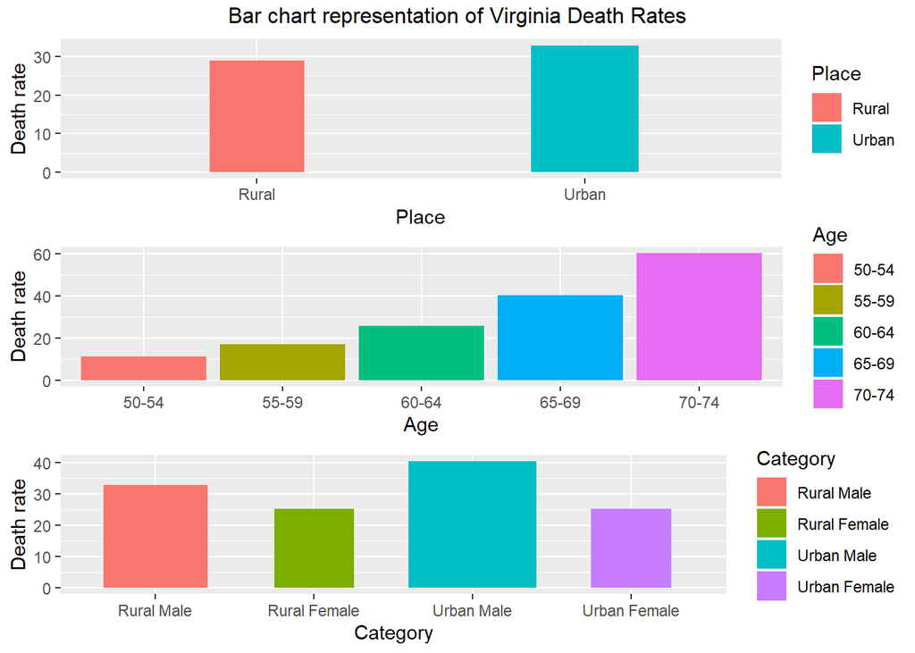

```r
#Grouping data based on age

ageGrouping <- aggregate(VADeathRate$Freq, by=list(Age=VADeathRate$Var1), FUN=mean)

#Grouping data based on category

catGrouping <- aggregate(VADeathRate$Freq, by=list(Category=VADeathRate$Var2), FUN=mean)

#Grouping data based on region

type1Grouping <- aggregate(VADeathRate$Freq, by=list(gender=VADeathRate$Var2), FUN=mean)
type1Grouping$Place <- c("Rural", "Rural", "Urban", "Urban")
placeGrouping <- aggregate(type1Grouping$x, by=list(Place=type1Grouping$Place), FUN=mean)

#Plotting different results

p1 <- ggplot(placeGrouping, aes(Place, x, fill=Place, width=x*0.01)) +

  geom_bar(stat="identity") +
  ylab("Death rate")

p2 <- ggplot(ageGrouping, aes(Age, x, fill = Age)) +

  geom_bar(stat="identity") +
  ylab("Death rate")



p3 <- ggplot(catGrouping, aes(Category, x, fill=Category, width=x*0.02)) +
  geom_bar(stat="identity") +
  geom_col(position = "dodge") +
  ylab("Death rate")

grid.arrange(p1, p2, p3, top = "Bar chart representation of Virginia Death Rates")
```

#### b) Multivariate analysis

Multivariate analysis (MVA) is based on the principles of multivariate statistics, which involves observation and analysis of more than one statistical outcome variable at a time. Typically, MVA is used to address the situations where multiple measurements are made on each experimental unit and the relations among these measurements and their structures are important.

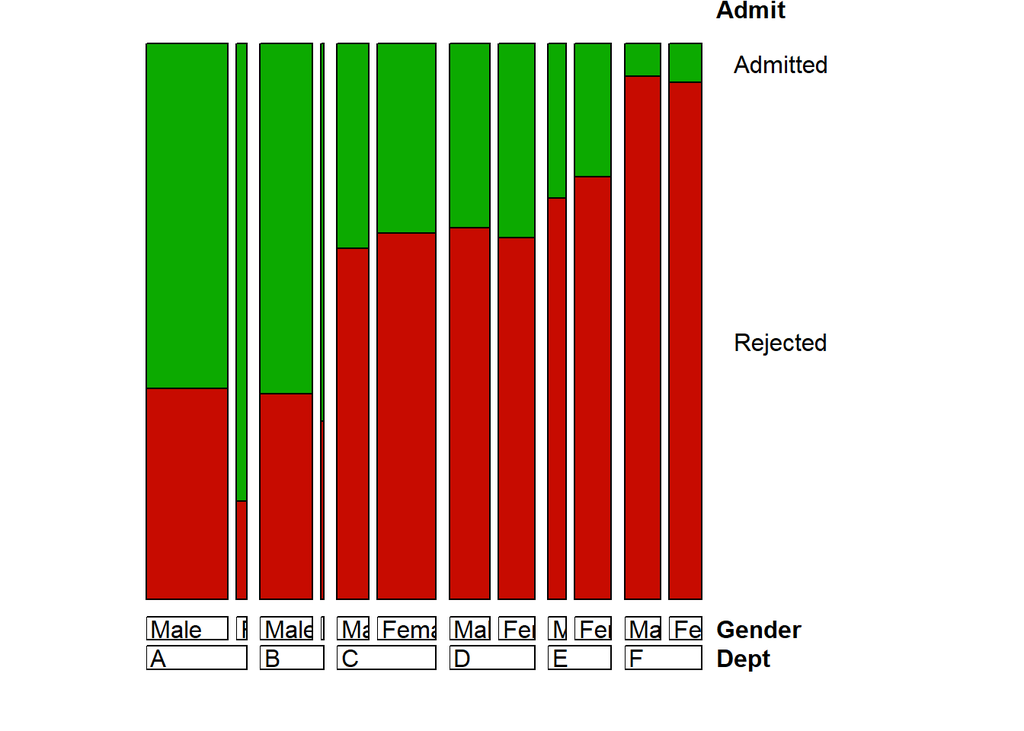

```r
uniAdmission <- as.data.frame.table(UCBAdmissions)
#Admission depending on dept and gender
doubledecker(Admit ~ Dept + Gender, data = UCBAdmissions, margins = c(0,6, 3, 0), keep_aspect_ratio = TRUE, gp = gpar(fill = c("#0caa00","#c70b00")))
```

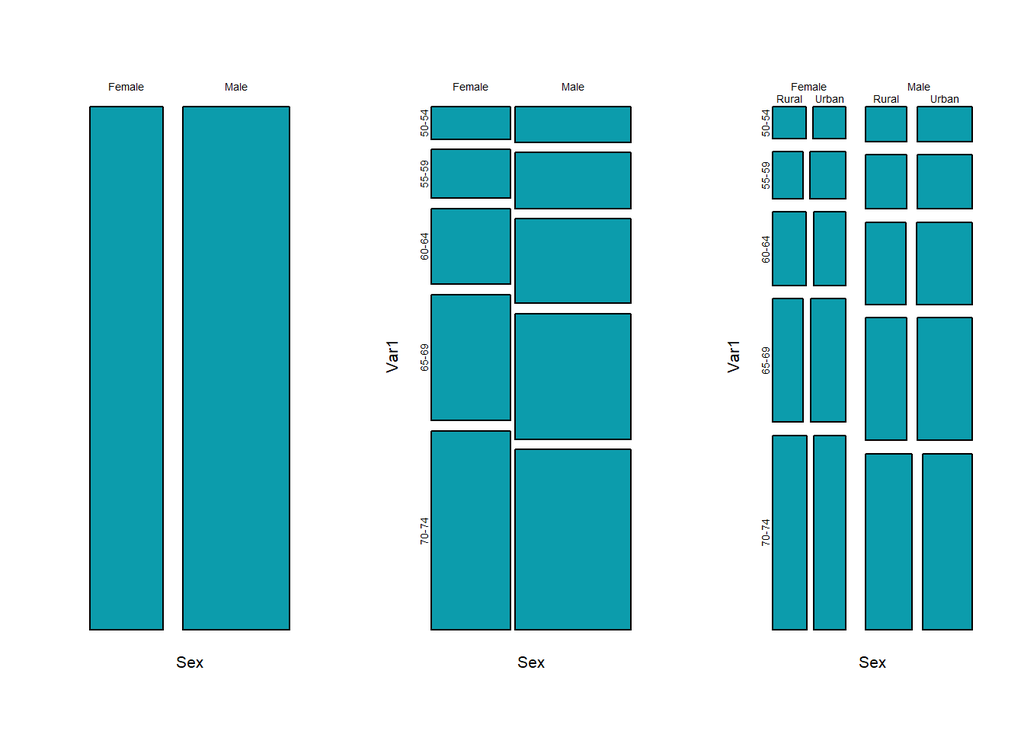

```r
#Death rates mosaics
addedCols <- VADeathRate
addedCols$Place <- c("Rural", "Rural", "Rural", "Rural", "Rural", "Rural", "Rural", "Rural", "Rural", "Rural", "Urban", "Urban", "Urban", "Urban", "Urban", "Urban", "Urban", "Urban", "Urban", "Urban")
addedCols$Sex <- c("Male", "Male", "Male", "Male", "Male", "Female", "Female", "Female", "Female", "Female", "Male", "Male", "Male", "Male", "Male", "Female", "Female", "Female", "Female", "Female")
par(mfrow=c(1,3))
m1 <- mosaicplot(xtabs(Freq ~ Sex, data=addedCols), main="", color = "#0c9cac", border = "black")
m2 <- mosaicplot(xtabs(Freq ~ Sex + Var1, data=addedCols),main="", color = "#0c9cac", border = "black")
m3 <- mosaicplot(xtabs(Freq ~ Sex + Var1 + Place, data=addedCols),main="", color = "#0c9cac", border = "black")
```

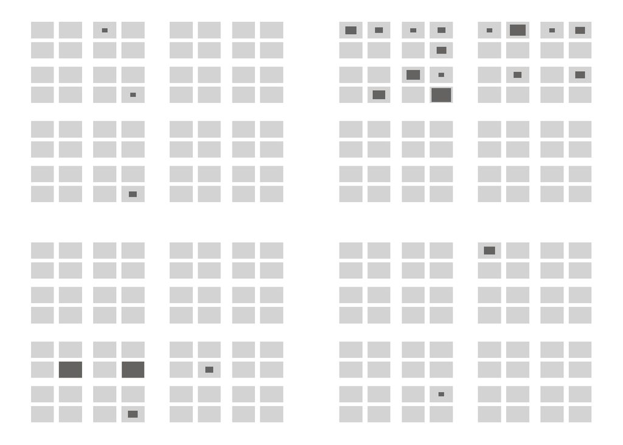

```r
data(Zoo, package="seriation")
fluctile(table(select(Zoo, c(hair, eggs:backbone))),label=FALSE)
```

### 2. Missing values and Outliers

### Missing

In aceasta parte a proiectului am construit un set de date in care este reprezentat PIB-ul pe fiecare Tara, investitia in sanatate si educatie respectiv HDI, iar tarile sunt impartite pe continente.

Urmatorul cod ne permite incarcarea datelor

```r
   data<-read.csv("data.csv",header=TRUE)
date<-data.frame(Indicator=data$Series.Code,
                 Tara=data$Country.Name,
                 Valoare=data$X2015..YR2015.
                 )

Continent<-data$Continent
HDI<- data$HDI
date<-reshape(date,idvar="Tara",timevar = "Indicator",direction="wide")
date<-data.frame(Tara=date$Tara,
                 PIBperCapita=date$Valoare.NY.GDP.PCAP.PP.CD,
                 CheltEducatie=date$Valoare.SE.XPD.TOTL.GD.ZS,
                 CO2perCapita=date$Valoare.EN.ATM.CO2E.PC,
                 CheltSanatate=date$Valoare.SH.XPD.GHED.GD.ZS
                 )
date<-data.frame(date,Continent)
date<-data.frame(date,HDI)
```

Am prelucrat datele introduse deoarece contine valori nule si valori aberante, inlocuindule cu valoarea lipsa.

```r
   for( i in 1:nrow(date)){
  for(j in 1:ncol(date)){
    if(date[i,j]==""||date[i,j]==".."){
      date[i,j]<-NA
    }
  }
}
```

Functia Care verifica valorile lipsa

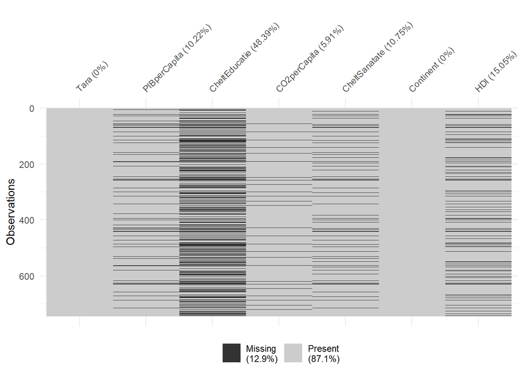

```r
vis_miss(date)
```

Elimina valorile lipsa folosind functia *na.omit()*.

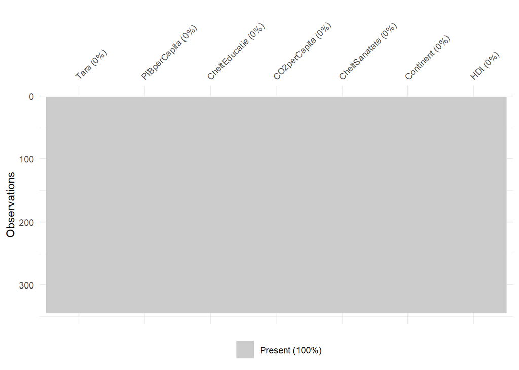

```r
date<-na.omit(date)
vis_miss(date)
```

### Outliers

Transformam datele in valori numerice pentru a putea fi scalate

```r
date$CO2perCapita<-as.numeric(date$CO2perCapita)
date$HDI<-as.numeric(date$HDI)
date$CheltEducatie<-as.numeric(date$CheltEducatie)
date$CheltSanatate<-as.numeric(date$CheltSanatate)
date$PIBperCapita<-as.numeric(date$PIBperCapita)
```

Pentru prima parte dorim sa verificam daca exista Outliers pentru PIB pentru toate tarile.

Afisam box plot pentru PIB pe toate tarile

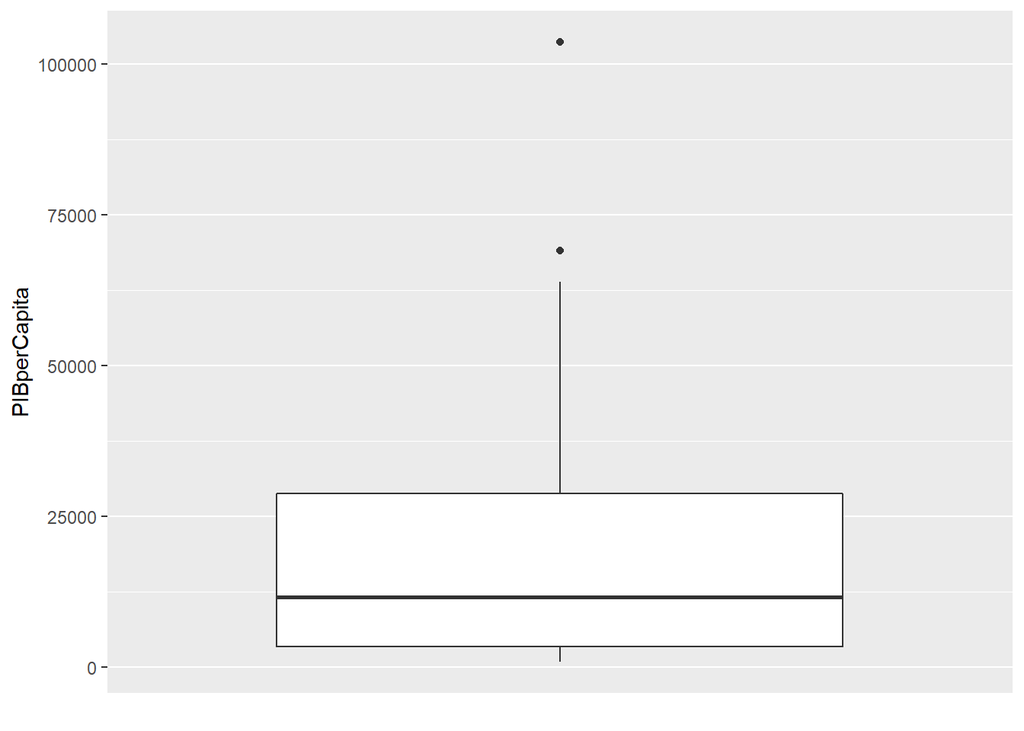

```r
ggplot(date, aes("PIB all Continent", y=PIBperCapita)) +
  xlab("") + geom_boxplot() +
  scale_x_discrete(breaks=NULL)
```

Comparam pibul pe fiecare continent cu pib-ul general folosind functia *grid.arrange()*

.

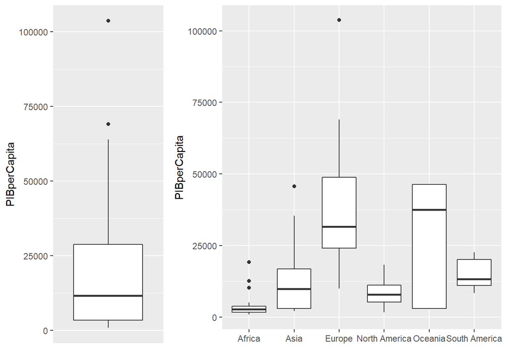

```r
all <- ggplot(date, aes("PIB all Continent", y=PIBperCapita)) +
  xlab("") + geom_boxplot() +
  scale_x_discrete(breaks=NULL)

continent1<-ggplot(date, aes(x=Continent, y=PIBperCapita)) +
  geom_boxplot() + xlab("")
grid.arrange(all,continent1, nrow=1,widths=c(1,2))
```

Analizam raportul cheluieli pentru sanatate si cheltuieli pentru educatia

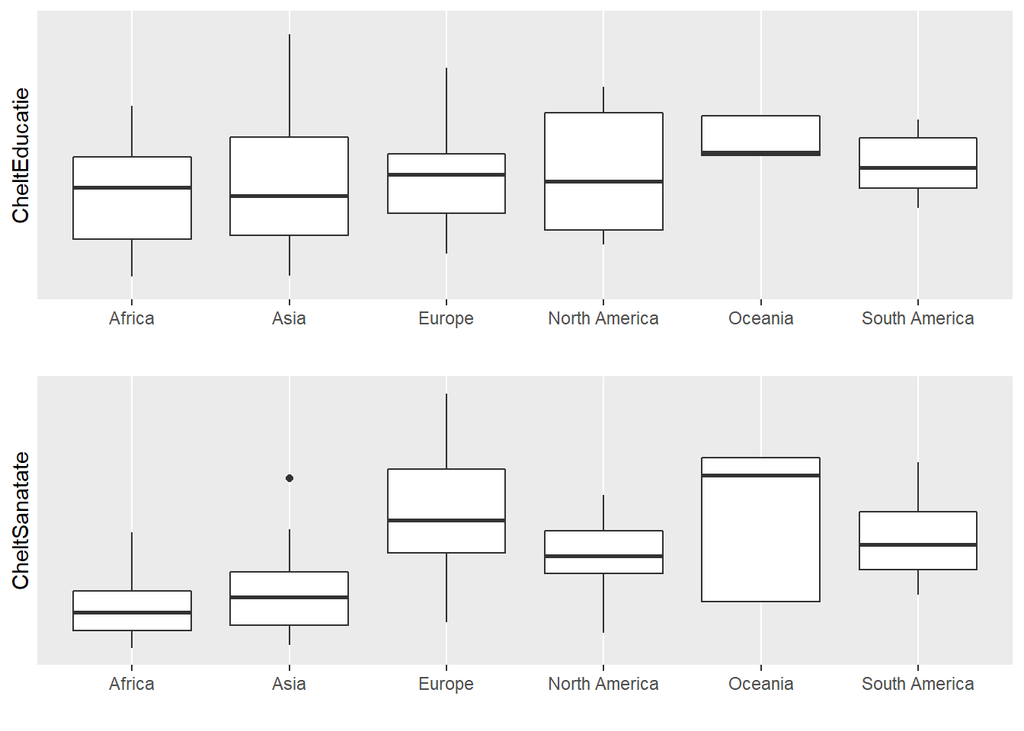

```r
educatie <- ggplot(date, aes(y=CheltEducatie, x=Continent)) +
  xlab("") + geom_boxplot() +
  scale_y_discrete(breaks=NULL)

sanatate <- ggplot(date, aes(y=CheltSanatate, x=Continent)) +
  xlab("") + geom_boxplot() +
  scale_y_discrete(breaks=NULL)
grid.arrange(educatie,sanatate)
```

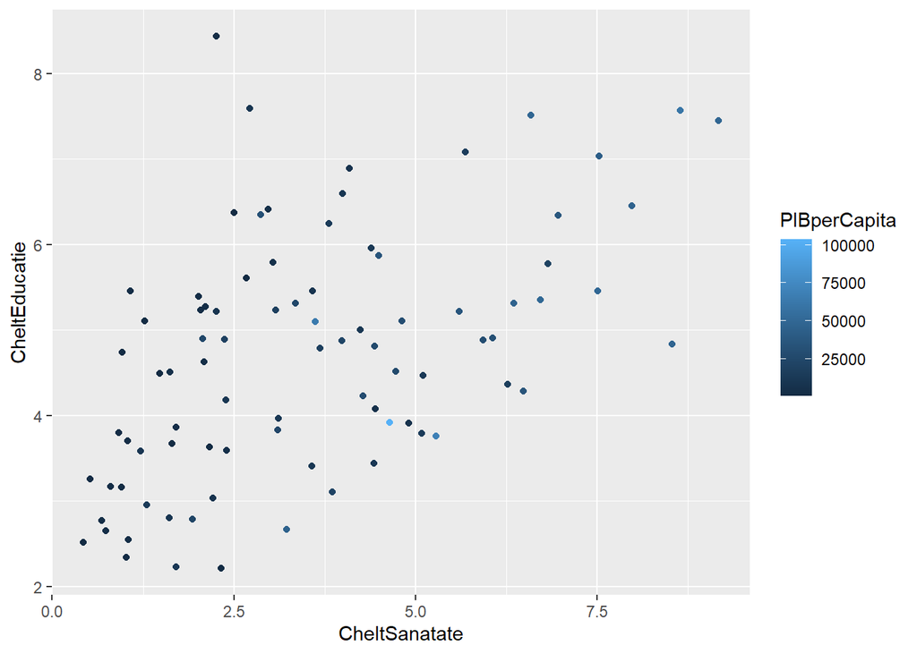

```r
ggplot(date)+aes(x=CheltSanatate,y=CheltEducatie ,colour=PIBperCapita )+geom_point()
```

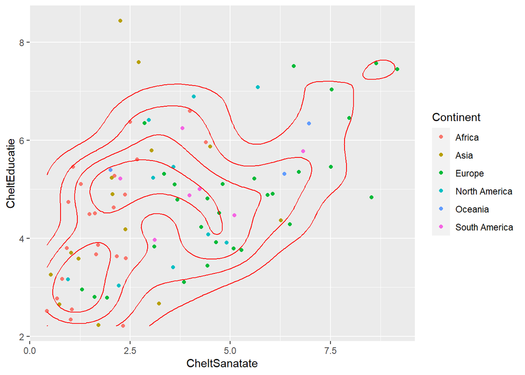

```r
ggplot(data=date)+ aes(x=CheltSanatate,y=CheltEducatie,colour=Continent) + geom_point() +
  geom_density2d(bins=5, col="red")
```

1).

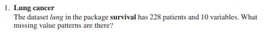

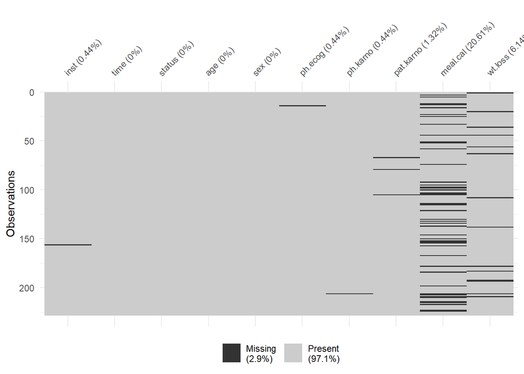

```r
library(survival)
date<-lung


vis_miss(date)
```

Exista valori lipsa pentru mai multe variabile, dar cele mai multe se gasesc la variabila “meal.cal”, urmata de variabila “wt.loss” si sunt putine observatii care au aceste valori lipsa pentru ambele variabile in acelasi timp Avem cate o valoare lipsa si pentru variabilele “inst, ph.ecog si ph.kamo”, dar aceasta nu lipseste pentru aceeasi observatie

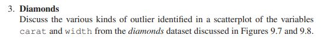

Figure 9.7

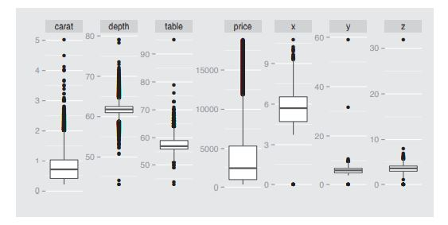

Figure 9.8

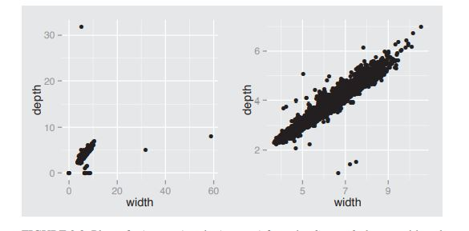

Observam ca in fig 9.7 variabila “carat” prezinta foarte multi outlieri cu valori peste limita superioara, deci aceasta variabila este inclinata spre dreapta. Fig 9.8 evidentiaza prezenta outlierilor si modul in care graficul se schimba atunci cand este redimensionat. In prima parte, cand dimensiunea era mai mare, prezenta valorilor extreme foarte mari atrag atentia si acele observatii par suspecte, pe cand, in a doua parte, valorile nu mai par foarte diferite unele de altele, facand ca graficul sa para un grafic obisnuit cu o variatie foarte mica a valorilor. Prezenta outlierilor atat pt varibila “carat” cat si pentru variabila “witdh” se poate explica prin faptul ca acest set de date contine foarte multe observatii si este normal sa existe si multe valori atipice.

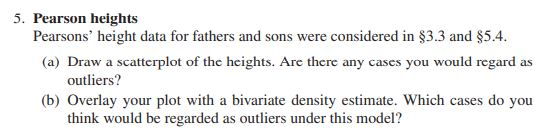

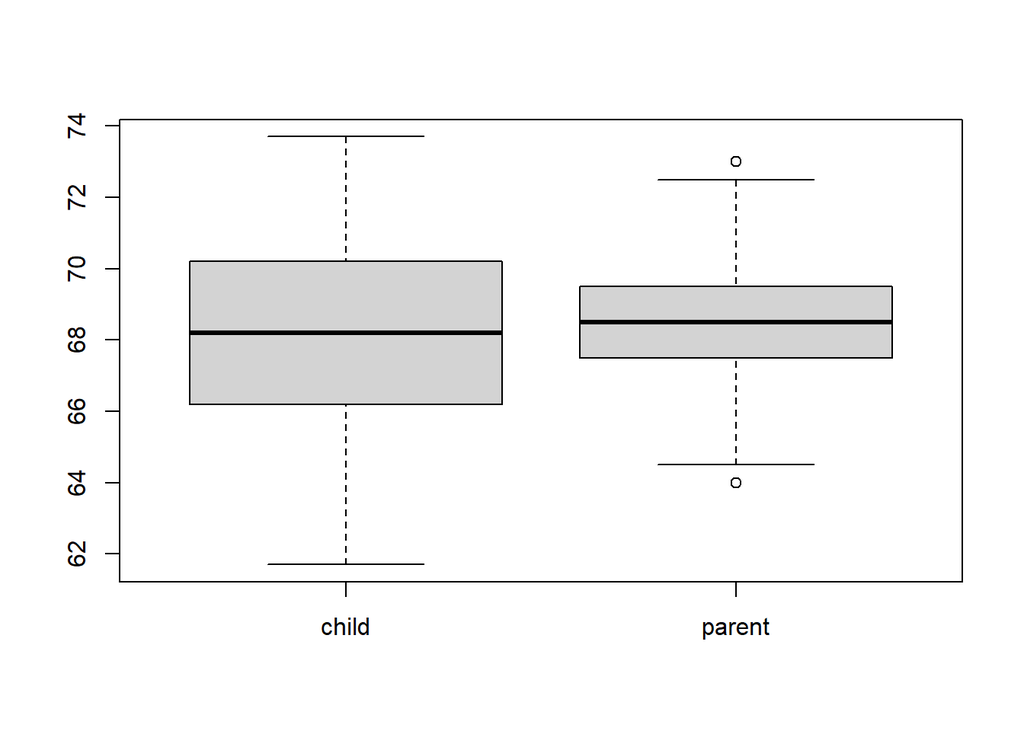

```r
data5<-galton

boxplot(data5)
```

1. Exista valori pe care le consideram outlieri pentru variabila “Inaltime parinti”

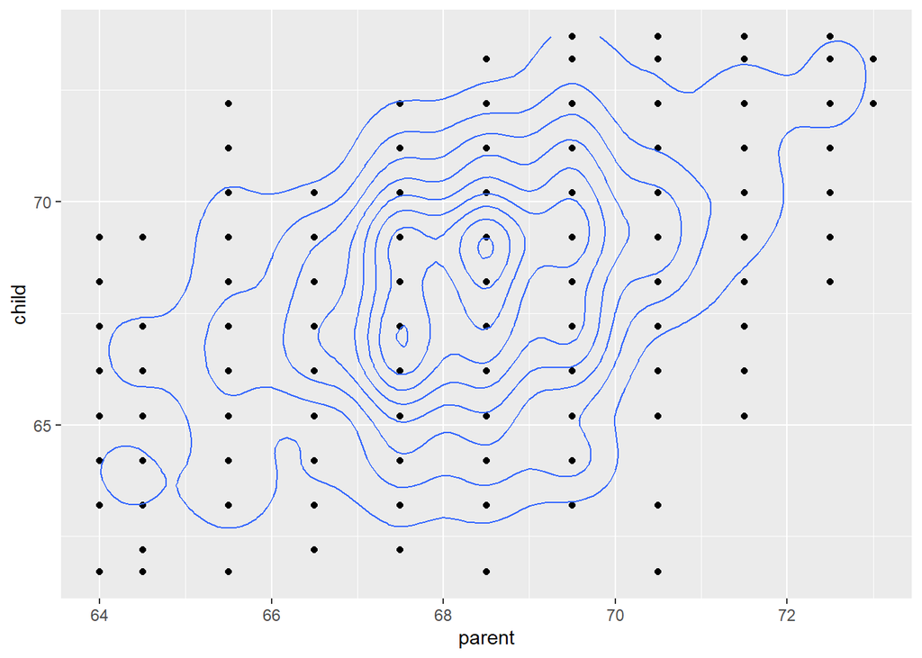

```r
ggplot(data5, aes( parent,child)) + geom_point() + geom_density2d()
```

2. Graficul densitatii bivariate arata faptul ca exista mai multi outlieri

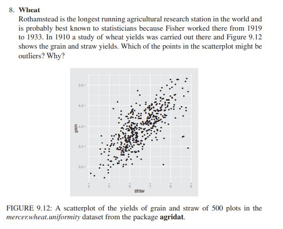

Am putea considera outlieri cele 2 puncte din partea dreapta jos a graficului deoarece acestea sunt departe de celelalte puncte ale graficului si se observa si o distanta considerabila intre ele.

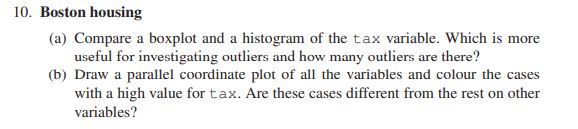

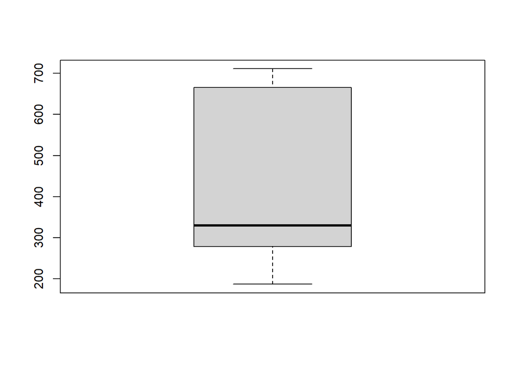

```r
attach(Boston)

boxplot(Boston$tax)
```

```r
boxplot.stats(Boston$tax)
```

```
## $stats
## [1] 187 279 330 666 711
##
## $n
## [1] 506
##
## $conf
## [1] 302.8173 357.1827
##
## $out
## numeric(0)
```

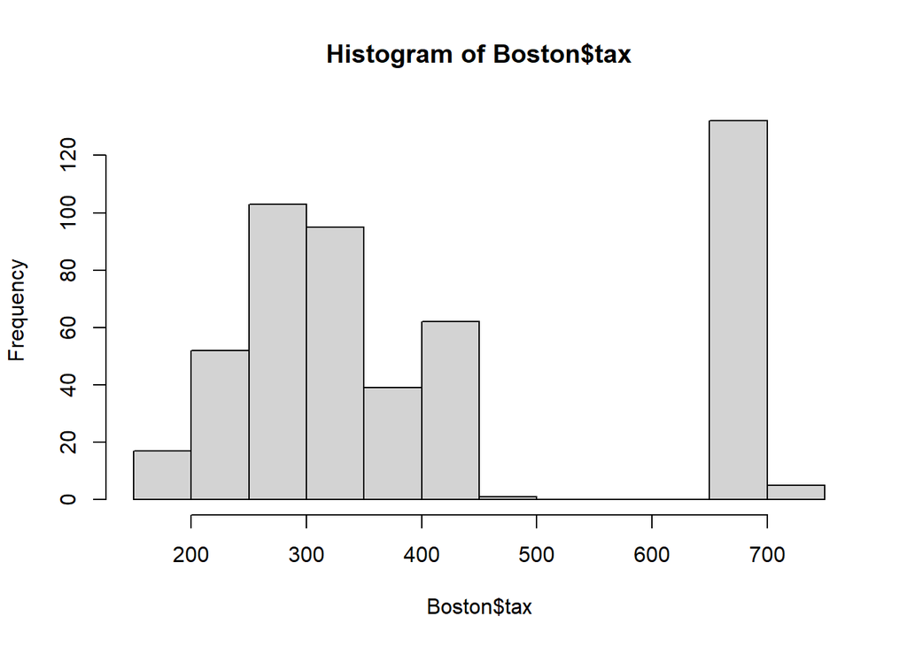

```r
hist(Boston$tax)
```

Mai util este boxplotul deoarece arata clar daca avem sau nu outlieri. Histograma arata faptul ca ar exista siniste valori mai mari, dar acestea nu sunt considerate ca fiind outlieri, deci ne poate induce in eroare.

```r
#names(Boston) <- c("crim", "zn", "indus", #"chas","nox","rm","age","dis","rad","tax","ptratio","black",
#                 "lstat", "medv")
#ggparcoord(data = Boston, columns = c(1:14), scale="uniminmax") + xlab("") + ylab("")
```

## Chapter 7 exercises

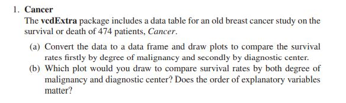

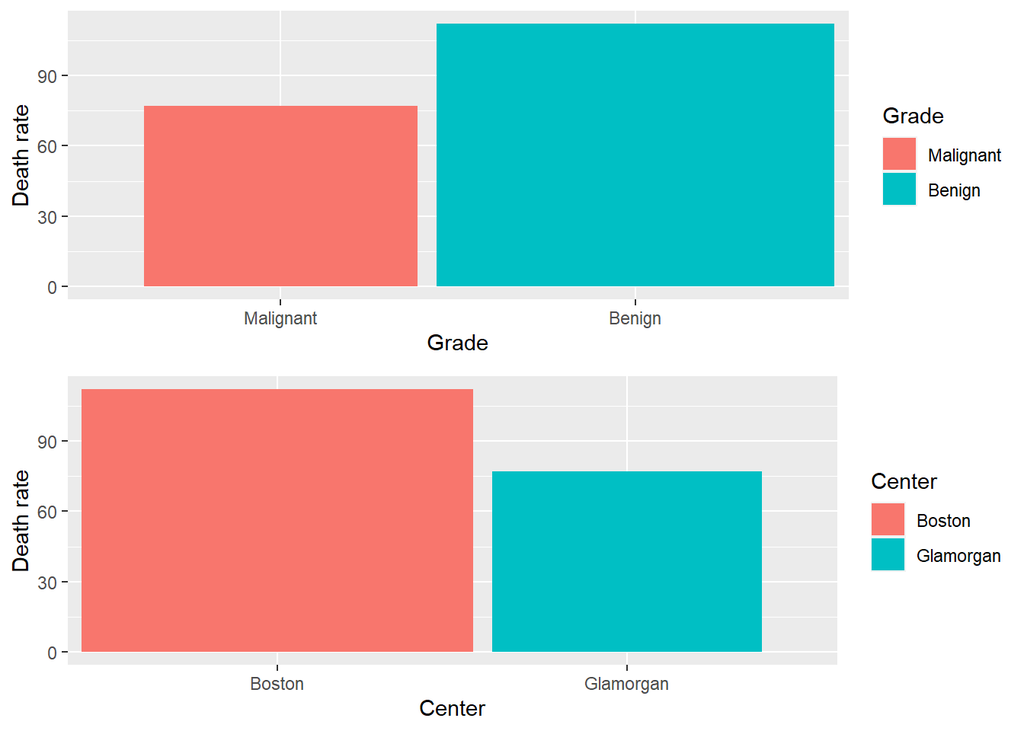

```r
##1
#a
library("vcdExtra")
cancer <- as.data.frame(Cancer)

hist1 <- ggplot(cancer, aes(Grade, Freq, fill=Grade, width=Freq*0.01)) +
  geom_bar(stat="identity") +
  ylab("Death rate")

hist2 <- ggplot(cancer, aes(Center, Freq, fill=Center, width=Freq*0.01)) +
  geom_bar(stat="identity") +
  ylab("Death rate")

grid.arrange(hist1, hist2)
```

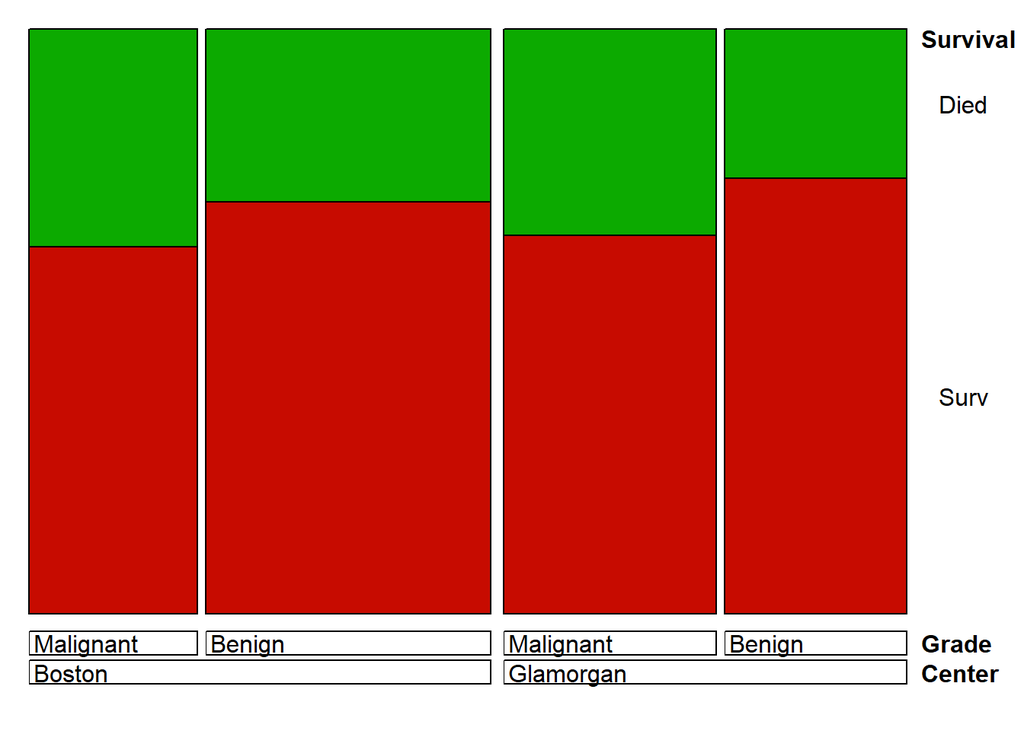

```r
#b
doubledecker(Survival ~ Center + Grade, data = Cancer,
             gp = gpar(fill = c("#0caa00","#c70b00")))
```

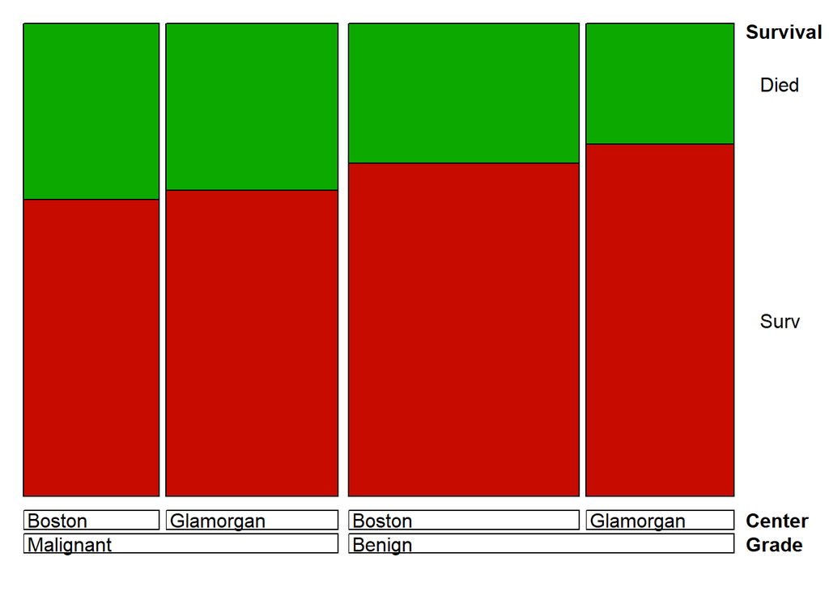

```r
doubledecker(Survival ~ Grade + Center, data = Cancer,
             gp = gpar(fill = c("#0caa00","#c70b00")))
```